# [Clostridium] hiranonis ASVs

Michael McLaren

2019-08-25

## Setup

```r
library(here)
library(phyloseq)
library(tidyverse)
library(ggbeeswarm)
library(ggthemes)
library(cowplot)
# Custom functions and plot setup
source(here("analysis", "functions-and-ggplot-setup.R"))
```

Load the microbiome profiles

```r
ps <- readRDS(here("results", "ps.Rds")) %>%
    subset_samples(Host_species %in% c("Canine", "Feline", "Equine",
            "Ovine")) %>%
    filter_taxa(function (x) sum(x) > 0, prune = TRUE)
ps
```

```
## phyloseq-class experiment-level object
## otu_table()   OTU Table:         [ 9928 taxa and 193 samples ]
## sample_data() Sample Data:       [ 193 samples by 22 sample variables ]
## tax_table()   Taxonomy Table:    [ 9928 taxa by 8 taxonomic ranks ]
## refseq()      DNAStringSet:      [ 9928 reference sequences ]
```

```r
tax <- tax_table(ps) %>% as_tibble %>% rename(ASV = Taxon)
glimpse(tax)
```

```
## Observations: 9,928
## Variables: 9
## $ ASV          <chr> "ASV1", "ASV2", "ASV3", "ASV4", "ASV5", "ASV6", "AS…
## $ Kingdom      <chr> "Bacteria", "Bacteria", "Bacteria", "Bacteria", "Ba…
## $ Phylum       <chr> "Proteobacteria", "Firmicutes", "Firmicutes", "Firm…
## $ Class        <chr> "Gammaproteobacteria", "Bacilli", "Clostridia", "Cl…
## $ Order        <chr> "Enterobacteriales", "Lactobacillales", "Clostridia…
## $ Family       <chr> "Enterobacteriaceae", "Enterococcaceae", "Lachnospi…
## $ Genus        <chr> "Escherichia/Shigella", "Enterococcus", NA, "Peptoc…
## $ Species      <chr> NA, NA, NA, NA, "equinus/gallolyticus/infantarius/l…
## $ NCBI_species <chr> NA, NA, NA, "[Clostridium] hiranonis", NA, NA, NA, …
```

We consider a sample as CD positive if CD was detected either in the lab assay or in the microbiome sequencing profiles.

```r
sample_data(ps)$CD <- sample_data(ps)$CD_either
```

## Review BLAST results

Summary of the BLAST results for all ASVs within 97% id of C. hiranonis (see `03-taxonomy.Rmd`):

```r
blast <- read_csv(here::here("results", "hiranonis-and-scindens.csv"))
blast %>%
    group_by(NCBI_acc, NCBI_species, Mismatches, Perc_ident) %>%
    summarize(Num_ASVs = n())
```

```
## # A tibble: 4 x 5
## # Groups:   NCBI_acc, NCBI_species, Mismatches [4]
##   NCBI_acc    NCBI_species            Mismatches Perc_ident Num_ASVs
##   <chr>       <chr>                        <dbl>      <dbl>    <int>
## 1 NR_028611.1 [Clostridium] hiranonis          0      100          1
## 2 NR_028611.1 [Clostridium] hiranonis          1       99.6       19
## 3 NR_028611.1 [Clostridium] hiranonis          2       99.2        3
## 4 NR_028785.1 [Clostridium] scindens           0      100          1
```

We have various ASVs within 99% identity of the available C. hiranonis 16S sequence, including one that is an exact match. These ASVs are labeled as “[Clostridium] hiranonis” in the tax table,

```r
tax %>%
    filter(NCBI_species == "[Clostridium] hiranonis") %>%
    .$ASV
```

```
##  [1] "ASV4"    "ASV62"   "ASV590"  "ASV629"  "ASV680"  "ASV854"  "ASV913"
##  [8] "ASV956"  "ASV1132" "ASV1133" "ASV1169" "ASV1370" "ASV1613" "ASV1705"
## [15] "ASV1713" "ASV2349" "ASV2460" "ASV2777" "ASV2860" "ASV3276" "ASV3634"
## [22] "ASV3833" "ASV5237"
```

Let’s get a data-frame version of the microbiome data w/ just the hiranonis strains. Each row will correspond to an ASV-Sample pair.

```r
hira <- ps %>%
    subset_taxa(str_detect(NCBI_species, "hiranonis")) %>%
    as_tibble(tax = FALSE) %>%
    mutate(Proportion = Abundance / Sample_sum, Present = Abundance > 0)
glimpse(hira)
```

```
## Observations: 4,439
## Variables: 28
## $ Taxon                                  <chr> "ASV4", "ASV62", "ASV590"…
## $ Sample                                 <chr> "CS1_EQ1", "CS1_EQ1", "CS…
## $ Abundance                              <int> 0, 0, 0, 0, 0, 0, 0, 0, 0…
## $ Host_species                           <chr> "Equine", "Equine", "Equi…
## $ Breed                                  <chr> "Oldenburg", "Oldenburg",…
## $ Age_reported                           <chr> NA, NA, NA, NA, NA, NA, N…
## $ Age_group                              <fct> Not applicable, Not appli…
## $ Age                                    <dbl> NA, NA, NA, NA, NA, NA, N…
## $ SexCS                                  <fct> MC, MC, MC, MC, MC, MC, M…
## $ Sex                                    <fct> M, M, M, M, M, M, M, M, M…
## $ Neutered                               <fct> Yes, Yes, Yes, Yes, Yes, …
## $ Ab_status                              <fct> Non-treated, Non-treated,…
## $ Ab_type                                <chr> "None reported", "None re…
## $ Ab_group                               <chr> NA, NA, NA, NA, NA, NA, N…
## $ GI_status                              <fct> Healthy, Healthy, Healthy…
## $ CD_lab                                 <fct> Negative, Negative, Negat…
## $ CD_toxigenic                           <fct> Negative, Negative, Negat…
## $ CD_ribotype                            <chr> "Negative", "Negative", "…
## $ Relevant_diagnosis_or_reason_for_visit <chr> "Fever and leukopenia - r…
## $ Sample_number                          <int> 1, 1, 1, 1, 1, 1, 1, 1, 1…
## $ Sequence_ID                            <chr> "CS1-EQ1", "CS1-EQ1", "CS…
## $ Year_sequenced                         <fct> 2018, 2018, 2018, 2018, 2…
## $ Sample_sum                             <dbl> 19019, 19019, 19019, 1901…
## $ CD_reads                               <dbl> 0, 0, 0, 0, 0, 0, 0, 0, 0…
## $ CD_either                              <fct> Negative, Negative, Negat…
## $ CD                                     <fct> Negative, Negative, Negat…
## $ Proportion                             <dbl> 0, 0, 0, 0, 0, 0, 0, 0, 0…
## $ Present                                <lgl> FALSE, FALSE, FALSE, FALS…
```

```r
hira.merged <- hira %>%
    group_by_at(vars("Sample", sample_variables(ps))) %>%
    summarize_at(vars(Abundance, Proportion), sum) %>%
    ungroup %>%
    mutate(Present = Abundance > 0)
```

## Prevalance of [Clostridium] hiranonis 99% OTU

Let’s first check the prevalance of C. hiranonis across host species,

```r
hira.merged %>%
    group_by(Host_species) %>%
    summarize(n_total = n(), n_present = sum(Present),
        Prevalance = mean(Present))
```

```
## # A tibble: 4 x 4
##   Host_species n_total n_present Prevalance
##   <chr>          <int>     <int>      <dbl>
## 1 Canine           104        55     0.529
## 2 Equine            69         1     0.0145
## 3 Feline            15        12     0.8
## 4 Ovine              5         0     0
```

With the exception of 1 equine sample, C. hiranonis is restricted to canines and felines.

Two-sided Fisher’s exact test of independence between C. hiranonis presence and C. difficile presence, for canines and felines:

```r
tb <- hira.merged %>%
    filter(Host_species %in% c("Canine", "Feline")) %>%
    rename(CH = Present) %>%
    group_by(Host_species, CD, CH) %>%
    count() %>%
    spread(CD, n, fill = 0)
tb
```

```
## # A tibble: 4 x 4
## # Groups:   Host_species, CH [4]
##   Host_species CH    Negative Positive
##   <chr>        <lgl>    <dbl>    <dbl>
## 1 Canine       FALSE       24       25
## 2 Canine       TRUE        47        8
## 3 Feline       FALSE        1        2
## 4 Feline       TRUE        12        0
```

```r
# Test canines:
tb[1:2,3:4]
```

```
## # A tibble: 2 x 2
##   Negative Positive
##      <dbl>    <dbl>
## 1       24       25
## 2       47        8
```

```r
fisher.test(tb[1:2,3:4])
```

```
##
##  Fisher's Exact Test for Count Data
##
## data:  tb[1:2, 3:4]
## p-value = 0.000109
## alternative hypothesis: true odds ratio is not equal to 1
## 95 percent confidence interval:
##  0.05596174 0.45062680
## sample estimates:
## odds ratio
##  0.1665538
```

```r
# Test felines:
tb[3:4,3:4]
```

```
## # A tibble: 2 x 2
##   Negative Positive
##      <dbl>    <dbl>
## 1        1        2
## 2       12        0
```

```r
fisher.test(tb[3:4,3:4])
```

```
##
##  Fisher's Exact Test for Count Data
##
## data:  tb[3:4, 3:4]
## p-value = 0.02857
## alternative hypothesis: true odds ratio is not equal to 1
## 95 percent confidence interval:
##  0.000000 1.086355
## sample estimates:
## odds ratio
##          0
```

## Prevalance of [Clostridium] hiranonis ASVs

Prevalence of various hiranonis ASVs across host species:

```r
hira %>%
    filter(Abundance > 0) %>%
    group_by(Host_species, Taxon) %>%
    count %>%
    arrange(Host_species, -n) %>%
    print(n=Inf)
```

```
## # A tibble: 27 x 3
## # Groups:   Host_species, Taxon [27]
##    Host_species Taxon       n
##    <chr>        <chr>   <int>
##  1 Canine       ASV4       55
##  2 Canine       ASV62      19
##  3 Canine       ASV590      3
##  4 Canine       ASV1705     2
##  5 Canine       ASV629      2
##  6 Canine       ASV854      2
##  7 Canine       ASV1169     1
##  8 Canine       ASV1370     1
##  9 Canine       ASV1613     1
## 10 Canine       ASV1713     1
## 11 Canine       ASV2349     1
```

[output cut: 16 more lines]

ASV4 is the most prevalent by far, ASV62 also has substantial prevalence in Canines, and all other ASVs appear only 1-3 times.

To try to get a better view of what’s going on, let’s lump together all the rare ASVS (the ones besides 4 and 62).

```r
hira0 <- hira %>%
    mutate(Taxon = ifelse(Taxon %in% c("ASV4", "ASV62"), Taxon, "Other")) %>%
    group_by_at(vars(Sample, Taxon, sample_variables(ps))) %>%
    summarize_at(vars(Abundance, Proportion), sum) %>%
    ungroup
hira0 %>%
    select(Sample, Taxon, Abundance, Proportion)
```

```
## # A tibble: 579 x 4
##    Sample     Taxon Abundance Proportion
##    <chr>      <chr>     <int>      <dbl>
##  1 CS1_EQ1    ASV4          0   0
##  2 CS1_EQ1    ASV62         0   0
##  3 CS1_EQ1    Other         0   0
##  4 CS10_OV3   ASV4          0   0
##  5 CS10_OV3   ASV62         0   0
##  6 CS10_OV3   Other         0   0
##  7 CS100_CN59 ASV4       1132   0.0545
##  8 CS100_CN59 ASV62         0   0
##  9 CS100_CN59 Other         0   0
## 10 CS101_CN60 ASV4          8   0.000364
## # … with 569 more rows
```

```r
tb <- hira0 %>%
    select(-Proportion) %>%
    spread(Taxon, Abundance) %>%
    filter(ASV4 + ASV62 + Other > 0) %>%
    mutate(CH_type = case_when(
            (ASV62 == 0) & (Other == 0) ~ "ASV4 only",
            (ASV62 > 0) & (Other == 0)  ~ "ASV4 + ASV62",
            (ASV62 > 0) & (Other > 0) ~ "ASV4, ASV62, + Other",
            (ASV62 == 0) & (Other > 0) ~ "ASV4 + Other"))
```

Let’s look at the co-occurrance of the three types

```r
tb %>%
    mutate_at(vars(ASV4, ASV62, Other), ~ . > 0) %>%
    group_by(ASV4, ASV62, Other) %>%
    count
```

```
## # A tibble: 4 x 4
## # Groups:   ASV4, ASV62, Other [4]
##   ASV4  ASV62 Other     n
##   <lgl> <lgl> <lgl> <int>
## 1 TRUE  FALSE FALSE    34
## 2 TRUE  FALSE TRUE     14
## 3 TRUE  TRUE  FALSE    14
## 4 TRUE  TRUE  TRUE      6
```

We always find ASV4 if any C. hiranonis is present. About 50% of the time we find ASV4 alone, and 50% of the time we find ASV4 with other ASVs. The other ASV is about equally likely to be ASV62 or some other ASV. We find ASV4, ASV62, and other hiranonis ASVs together in 6 samples.

Let’s look at the ratio of reads of all non-ASV4 to ASV4 in samples with non-ASV4:

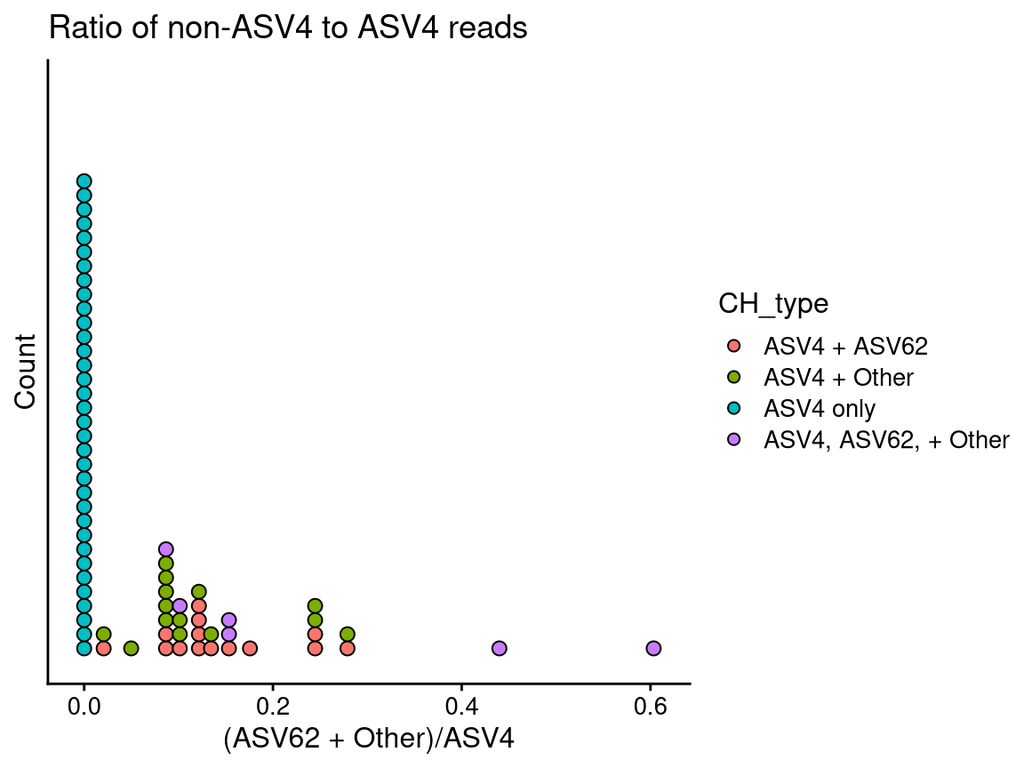

```r
tb %>%
    ggplot(aes((ASV62 + Other) / ASV4, fill = CH_type)) +
    geom_dotplot(stackgroups = TRUE, binpositions = "all", binwidth = 0.015) +
    scale_y_continuous(breaks = c()) +
    labs(y = "Count", title = "Ratio of non-ASV4 to ASV4 reads")
```

Another way to look at the co-abundance pattern is to plot the number of reads from non-ASV4 ASVs against ASV4 on a log scale,

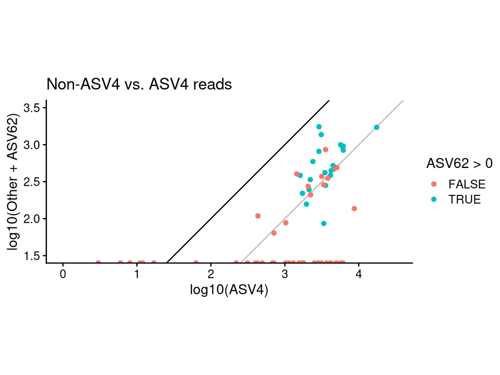

```r
tb %>%
    filter(ASV4 > 0) %>%
    ggplot(aes(log10(ASV4), log10(Other + ASV62), color = ASV62 > 0)) +
    geom_abline(color = "black" ) +
    geom_abline(intercept = -1, color = "grey") +
    geom_point() +
    coord_fixed(xlim = c(0, 4.5), ylim = c(1.5, 3.5)) +
    labs(title = "Non-ASV4 vs. ASV4 reads")
```

Shown for scale is a black line corresponding to a 1:1 ratio and a grey line corresponding to a 1:10 ratio.

These figures shows that we only have other ASVs when we have ASV4 also present and in a higher abundance. This suggests that we have various strains of C. hiranonis for which most to all 16S copies in C. hiranonis are ASV4 in the amplified region, and some strains have other ASVs at a minority of 16S copies.

Consistent with this hypothesis, is the fact that we should expect C. hiranonis to have around 12 copies of the 16S gene, based on the fact that it’s closest relative in the rrnDB is C. difficile, which is found to have 12 copies in nearly all of the ~50 C. difficile genomes in the database. (See below)

This data indicates that we likely have a variety of C. hiranonis strains, but most are too rare to try to consider their individual effect on C. difficile. Therefore, going forward we might consider two approaches; first, is to aggregate all C. hiranonis ASVs into a single 99% identity C. hiranonis OTU. Second is to classify samples into three categories: No C. hiranonis present, ASV4 present, and both ASV4 and ASV62 present.

## 16S copy number

The rrnDB contains a currated list of taxonomically classified genomes with 16S copy-number estimates. C. hiranonis is not represented in the database, and so we must estimate it’s copy number from related strains. Using the [online portal to the RDP classifier](https://rrndb.umms.med.umich.edu/estimate/) on the C. hiranonis ASVs resulted in classification of all ASVs to the RDP genus “Clostridium XI” in the family Peptostreptococcaceae, which is the same RDP genus containing C. difficile. The records for this genus can be viewed here: [Clostridium XI copy numbers](https://rrndb.umms.med.umich.edu/genomes/browser?superkingdom=&phylum=&tax_class=&order=&family=&genus=Clostridium+XI&taxonomy=16&button=Go) and are summarized by

| Genus | Genomes | Range | Mode | Median | Mean | Std Dev |
| --- | --- | --- | --- | --- | --- | --- |
| Clostridium XI | 49 | 10 - 17 | 12 | 12 | 12.0 | 0.80 |

Of these 49 genomes, 48 are clasified as C. difficile, have a range of 10-12, and nearly all have a copy number of 12. The remaining genome has a copy number of 17 and is classified as Paeniclostridium sordellii.

On the whole, this suggests that the copy number of C. hiranonis is likely to at least around 10, indicating that it is plausible to see such a variety of ASVs co-occuring in the same genomes with and at lower abundance than ASV4.